# Brazilian High Education General Perspective

Expedito Pinto de Paula Junior

8/10/2020

# 1.Context

The [INEP](https://www.gov.br/inep/pt-br/acesso-a-informacao/institucional) is brazilian institute for education reasearch in Ministry of Education. Some of the competences of INEP are:

- Subsidize the public authorities in the monitoring and evaluation of the National Education System.
- Support policy planning to guarantee the right to quality education for each and every one.
- Propose and define performance parameters, criteria and mechanisms for the evaluation of education systems at all levels and modalities, as well as for the skills certification processes, in conjunction with the education systems of the states, the Federal District and the municipalities.
- Others…

Every year, INEP perform the National Student Performance Exam ([ENADE](http://inep.gov.br/enade)) in order to evaluates the performance of graduates of undergraduate courses in relation to the syllabus provided in the curricular guidelines of the courses, the development of competences and skills necessary to deepen general and professional training, and the level of updating of students in relation to the Brazilian and world reality.

In INEP Web site are available several datasets denomitate “[The INEP Microdata](http://inep.gov.br/web/guest/microdados)”, these datasets constitute the lowest level of disaggregation of data collected by surveys, evaluations and examinations.

Each edition (year) of the evaluation has focus in different fields of study. More information about it are available in “[Exame Nacional de Desempenho de Estudantes](https://pt.wikipedia.org/wiki/Exame_Nacional_de_Desempenho_de_Estudantes)”

# 2.Synopsis

Using Exploratory Data Analysis method this analysis explore the [The INEP Microdata](http://inep.gov.br/web/guest/microdados) and address some basic questions about the National Student Performance Exam in the last 10 years:

- 1. Is higher education in Brazil improving?
- 2. Where Brazil have the best number in education? per área and also per courses.
- 3. In relation to the past generation, is higher education improving?
- 4. In what modalities of higher education is Brazil improving?
- 5. Which courses in which college are best rated?

# 3.Data Processing

## 3.1 Prerequisite libraries

```r
library(ggplot2)
library(knitr)
library(kableExtra)
library(dplyr)
library(arsenal)
library(readxl)
```

## 3.2 Data Loading

The last 10 years available in [The INEP Microdata](http://inep.gov.br/web/guest/microdados) are from 2008 to 2018.

```r
# !WARNING! Large Data - must wait to finish all downloads.
# Download files from web
fileUrl2008 <- "http://download.inep.gov.br/microdados/Enade_Microdados/microdados_enade_2008.zip"
if(!file.exists("./data/microdados_enade_2008.zip")){
     download.file(fileUrl2008, destfile = "./data/microdados_enade_2008.zip")
}

fileUrl2009 <- "http://download.inep.gov.br/microdados/Enade_Microdados/microdados_enade_2009.zip"
if(!file.exists("./data/microdados_enade_2009.zip")){
     download.file(fileUrl2009, destfile = "./data/microdados_enade_2009.zip")
}

fileUrl2010 <- "http://download.inep.gov.br/microdados/Enade_Microdados/microdados_enade_2010.zip"
if(!file.exists("./data/microdados_enade_2010.zip")){
     download.file(fileUrl2010, destfile = "./data/microdados_enade_2010.zip")
}

fileUrl2011 <- "http://download.inep.gov.br/microdados/Enade_Microdados/microdados_enade_2011.zip"
if(!file.exists("./data/microdados_enade_2011.zip")){
     download.file(fileUrl2011, destfile = "./data/microdados_enade_2011.zip")
}

fileUrl2012 <- "http://download.inep.gov.br/microdados/Enade_Microdados/microdados_enade_2012.zip"
if(!file.exists("./data/microdados_enade_2012.zip")){
     download.file(fileUrl2011, destfile = "./data/microdados_enade_2012.zip")
}

fileUrl2013 <- "http://download.inep.gov.br/microdados/Enade_Microdados/microdados_enade_2013.zip"
if(!file.exists("./data/microdados_enade_2013.zip")){
     download.file(fileUrl2013, destfile = "./data/microdados_enade_2013.zip")
}

fileUrl2014 <- "http://download.inep.gov.br/microdados/Enade_Microdados/microdados_enade_2014.zip"
if(!file.exists("./data/microdados_enade_2014.zip")){
     download.file(fileUrl2014, destfile = "./data/microdados_enade_2014.zip")
}

fileUrl2015 <- "http://download.inep.gov.br/microdados/Enade_Microdados/microdados_enade_2015.zip"
if(!file.exists("./data/microdados_enade_2015.zip")){
     download.file(fileUrl2015, destfile = "./data/microdados_enade_2015.zip")
}

fileUrl2016 <- "http://download.inep.gov.br/microdados/Enade_Microdados/microdados_enade_2016_versao_28052018.zip"
if(!file.exists("./data/microdados_enade_2016_versao_28052018.zip")){
     download.file(fileUrl2016, destfile = "./data/microdados_enade_2016_versao_28052018.zip")
}

fileUrl2017 <- "http://download.inep.gov.br/microdados/Enade_Microdados/microdados_Enade_2017_portal_2018.10.09.zip"
if(!file.exists("./data/microdados_Enade_2017_portal_2018.10.09.zip")){
     download.file(fileUrl2017, destfile = "./data/microdados_Enade_2017_portal_2018.10.09.zip")
}

fileUrl2018 <- "http://download.inep.gov.br/microdados/Enade_Microdados/microdados_enade_2018.zip"
if(!file.exists("./data/microdados_enade_2018.zip")){
     download.file(fileUrl2018, destfile = "./data/microdados_enade_2018.zip")
}

CourseCode <- "http://download.inep.gov.br/informacoes_estatisticas/legislacao/2017/tabela_de_cursos.xls"
if(!file.exists("./data/tabela_de_curso.xls")){
     download.file(CourseCode, destfile = "./data/tabela_de_curso.xls")
}

# Load data from files
if(!exists("tblCursos")){
        tblCursos <- read_xls("./data/tabela_de_curso.xls")
}
if(!exists("mData2008")){
        mData2008 <- read.csv(unz("./data/microdados_enade_2008.zip", "2.DADOS/microdados_enade_2008.csv"), header = TRUE, sep = ";")
}
if(!exists("mData2009")){
        mData2009 <- read.csv(unz("./data/microdados_enade_2009.zip", "2.DADOS/microdados_enade_2009.csv"), header = TRUE, sep = ";")
}

# Change read pattern
if(!exists("mData2010")){
        mData2010 <- read.csv(unz("./data/microdados_enade_2010.zip", "3.DADOS/MICRODADOS_ENADE_2010.txt"), header = TRUE, sep = ";")
}

if(!exists("mData2011")){
        mData2011 <- read.csv(unz("./data/microdados_enade_2011.zip", "3.DADOS/MICRODADOS_ENADE_2011.txt"), header = TRUE, sep = ";")
}

# The file name is correct according with the download zip file from ENADE Website.
if(!exists("mData2012")){
        mData2012 <- read.csv(unz("./data/microdados_enade_2012.zip", "3.DADOS/MICRODADOS_ENADE_2011.txt"), header = TRUE, sep = ";")
}

if(!exists("mData2013")){
        mData2013 <- read.csv(unz("./data/microdados_enade_2013.zip", "3.DADOS/MICRODADOS_ENADE_2013.txt"), header = TRUE, sep = ";")
}

if(!exists("mData2014")){
        mData2014 <- read.csv(unz("./data/microdados_enade_2014.zip", "3.DADOS/MICRODADOS_ENADE_2014.txt"), header = TRUE, sep = ";")
}

if(!exists("mData2015")){
        mData2015 <- read.csv(unz("./data/microdados_enade_2015.zip", "3.DADOS/MICRODADOS_ENADE_2015.txt"), header = TRUE, sep = ";")
}

if(!exists("mData2016")){
        mData2016 <- read.csv(unz("./data/microdados_enade_2016_versao_28052018.zip", "microdados_enade2016/3.DADOS/MICRODADOS_ENADE_2016.txt"), header = TRUE, sep = ";")
}

if(!exists("mData2017")){
        mData2017 <- read.csv(unz("./data/microdados_Enade_2017_portal_2018.10.09.zip", "3.DADOS/MICRODADOS_ENADE_2017.txt"), header = TRUE, sep = ";")
}

if(!exists("mData2018")){
        mData2018 <- read.csv(unz("./data/microdados_enade_2018.zip", "2018/3.DADOS/microdados_enade_2018.txt"), header = TRUE, sep = ";")
}
```

## 3.2 Identifing variables

Once that data is loaded is possible to identify that each year the number of variables is different than others years. For our study based in the dataset and accordding with the documentation available, the set of variables to be used in this analysis are list bellow:

| Table 1: Interest variables, datasets from 2008 to 2009 Variables | Table 1: Interest variables, datasets from 2008 to 2009 Description |
| --- | --- |
| nu_ano | Year of testing |
| co_grupo | ENADE course code group |
| co_subarea | ENADE course code subgroup |
| co_regiao_habil | Brazil region |
| co_uf_habil | Brazilian State |
| nu_idade | Student Age |
| tp_sexo | Sex |
| ano_fim_2g | High School Finish Year |
| ano_in_gra | Upper Graduation Start Year |
| QE_I13 | Question: What is your father’s education level? |
| QE_I14 | Question: What is your father’s education level? |
| nt_fg | Gross test score of general graduation |
| nt_ce | Gross test score of the specific component |
| nt_ger | Gross test score |

From 2010 until 2016 the interest variables change according with list bellow:

| Table 2: Interest variables, datasets from 2010 to 2016 Variables | Table 2: Interest variables, datasets from 2010 to 2016 Description |
| --- | --- |
| NU_ANO | Year of testing |
| CO_GRUPO | ENADE course code group |
| CO_CURSO | ENADE course code subgroup |
| CO_REGIAO_CURSO | Brazil region |
| CO_UF_CURSO | Brazilian State |
| NU_IDADE | Student Age |
| TP_SEXO | Sex |
| ANO_FIM_2G | High School Finish Year |
| ANO_IN_GRAD | Upper Graduation Start Year |
| QE_I13 | Question: What is your father’s education level? |
| QE_I14 | Question: What is your father’s education level? |
| NT_FG | Gross test score of general graduation |
| NT_CE | Gross test score of the specific component |
| NT_GER | Gross test score |

From 2017 until 2018 the interest variables change according with list bellow:

| Table 3: Interest variables, datasets from 2017 to 2018 Variables | Table 3: Interest variables, datasets from 2017 to 2018 Description |
| --- | --- |
| NU_ANO | Year of testing |
| CO_GRUPO | ENADE course code group |
| CO_CURSO | ENADE course code subgroup |
| CO_REGIAO_CURSO | Brazil region |
| CO_UF_CURSO | Brazilian State |
| NU_IDADE | Student Age |
| TP_SEXO | Sex |
| ANO_FIM_EM | High School Finish Year |
| ANO_IN_GRAD | Upper Graduation Start Year |
| QE_I13 | Question: What is your father’s education level? |
| QE_I14 | Question: What is your father’s education level? |
| NT_FG | Gross test score of general graduation |
| NT_CE | Gross test score of the specific component |
| NT_GER | Gross test score |

## 3.3 Extracting data subset and converge variable names

Based in the difference from the two previous tables, we are going two extract the varialbles from the datasets and convert to variable names from 2010 to 2018. Other important point to analysis is create a unique dataset for all years.

### 3.3.1 Identifying possible filters parameters.

| Table 4: Filters from 2008 to 2018 Variables | Table 4: Filters from 2008 to 2018 Description | Table 4: Filters from 2008 to 2018 Value |
| --- | --- | --- |
| tp_pres/TP_PRES | Presence Type | 555 = Present |
| tp_pr_ger/TP_PR_GER | Presence Type In Test | 555 = OK |
| tp_pr_ob_fg/TP_PR_OB_FG | Presence Type In Test for General Formation in Objective part | 555 = OK |
| tp_pr_di_fg/TP_PR_DI_FG | Presence Type In Test for General Formation in Discursive part | 555 = OK |
| tp_pr_ob_ce/TP_PR_OB_CE | Presence Type In Test for Specific Component in Objective part | 555 = OK |

### 3.3.2 Subset data

```r
# Filter and get interest variables
mData2008Filter <- subset(mData2008, tp_pres == 555 | tp_pr_ger == 555 | tp_pr_ob_fg == 555 | tp_pr_di_fg == 555 | tp_pr_ob_ce == 555, select = c(nu_ano,co_grupo,co_subarea,co_regiao_habil,co_uf_habil,nu_idade,tp_sexo,ano_fim_2g,ano_in_gra,QE_I13,QE_I14,nt_fg,nt_ce,nt_ger))
mData2009Filter <- subset(mData2009, tp_pres == 555 | tp_pr_ger == 555 | tp_pr_ob_fg == 555 | tp_pr_di_fg == 555 | tp_pr_ob_ce == 555, select = c(nu_ano,co_grupo,co_subarea,co_regiao_habil,co_uf_habil,nu_idade,tp_sexo,ano_fim_2g,ano_in_gra,QE_I13,QE_I14,nt_fg,nt_ce,nt_ger))
mData2010Filter <- subset(mData2010, TP_PRES == 555 | TP_PR_GER == 555 | TP_PR_OB_FG == 555 | TP_PR_DI_FG == 555 | TP_PR_OB_CE == 555, select = c(NU_ANO,CO_GRUPO,CO_CURSO, CO_REGIAO_CURSO, CO_UF_CURSO, NU_IDADE, TP_SEXO, ANO_FIM_2G, ANO_IN_GRAD, QE_I13, QE_I14, NT_FG, NT_CE, NT_GER))
mData2011Filter <- subset(mData2011, TP_PRES == 555 | TP_PR_GER == 555 | TP_PR_OB_FG == 555 | TP_PR_DI_FG == 555 | TP_PR_OB_CE == 555, select = c(NU_ANO,CO_GRUPO,CO_CURSO, CO_REGIAO_CURSO, CO_UF_CURSO, NU_IDADE, TP_SEXO, ANO_FIM_2G, ANO_IN_GRAD, QE_I13, QE_I14, NT_FG, NT_CE, NT_GER))
mData2012Filter <- subset(mData2012, TP_PRES == 555 | TP_PR_GER == 555 | TP_PR_OB_FG == 555 | TP_PR_DI_FG == 555 | TP_PR_OB_CE == 555, select = c(NU_ANO,CO_GRUPO,CO_CURSO, CO_REGIAO_CURSO, CO_UF_CURSO, NU_IDADE, TP_SEXO, ANO_FIM_2G, ANO_IN_GRAD, QE_I13, QE_I14, NT_FG, NT_CE, NT_GER))
mData2013Filter <- subset(mData2013, TP_PRES == 555 | TP_PR_GER == 555 | TP_PR_OB_FG == 555 | TP_PR_DI_FG == 555 | TP_PR_OB_CE == 555, select = c(NU_ANO,CO_GRUPO,CO_CURSO, CO_REGIAO_CURSO, CO_UF_CURSO, NU_IDADE, TP_SEXO, ANO_FIM_2G, ANO_IN_GRAD, QE_I13, QE_I14, NT_FG, NT_CE, NT_GER))
mData2014Filter <- subset(mData2014, TP_PRES == 555 | TP_PR_GER == 555 | TP_PR_OB_FG == 555 | TP_PR_DI_FG == 555 | TP_PR_OB_CE == 555, select = c(NU_ANO,CO_GRUPO,CO_CURSO, CO_REGIAO_CURSO, CO_UF_CURSO, NU_IDADE, TP_SEXO, ANO_FIM_2G, ANO_IN_GRAD, QE_I13, QE_I14, NT_FG, NT_CE, NT_GER))
mData2015Filter <- subset(mData2015, TP_PRES == 555 | TP_PR_GER == 555 | TP_PR_OB_FG == 555 | TP_PR_DI_FG == 555 | TP_PR_OB_CE == 555, select = c(NU_ANO,CO_GRUPO,CO_CURSO, CO_REGIAO_CURSO, CO_UF_CURSO, NU_IDADE, TP_SEXO, ANO_FIM_2G, ANO_IN_GRAD, QE_I13, QE_I14, NT_FG, NT_CE, NT_GER))
mData2016Filter <- subset(mData2016, TP_PRES == 555 | TP_PR_GER == 555 | TP_PR_OB_FG == 555 | TP_PR_DI_FG == 555 | TP_PR_OB_CE == 555, select = c(NU_ANO,CO_GRUPO,CO_CURSO, CO_REGIAO_CURSO, CO_UF_CURSO, NU_IDADE, TP_SEXO, ANO_FIM_2G, ANO_IN_GRAD, QE_I13, QE_I14, NT_FG, NT_CE, NT_GER))
mData2017Filter <- subset(mData2017, TP_PRES == 555 | TP_PR_GER == 555 | TP_PR_OB_FG == 555 | TP_PR_DI_FG == 555 | TP_PR_OB_CE == 555, select = c(NU_ANO,CO_GRUPO,CO_CURSO, CO_REGIAO_CURSO, CO_UF_CURSO, NU_IDADE, TP_SEXO, ANO_FIM_EM, ANO_IN_GRAD, QE_I13, QE_I14, NT_FG, NT_CE, NT_GER))
mData2018Filter <- subset(mData2018, TP_PRES == 555 | TP_PR_GER == 555 | TP_PR_OB_FG == 555 | TP_PR_DI_FG == 555 | TP_PR_OB_CE == 555, select = c(NU_ANO,CO_GRUPO,CO_CURSO, CO_REGIAO_CURSO, CO_UF_CURSO, NU_IDADE, TP_SEXO, ANO_FIM_EM, ANO_IN_GRAD, QE_I13, QE_I14, NT_FG, NT_CE, NT_GER))

# Binding rows for a UNIQUE DataSet
mData <- rbind(mData2008Filter, mData2009Filter)

#Change variable names according with year variables change from dataset (2010 to 2016)
colnames(mData) <- c("NU_ANO","CO_GRUPO","CO_CURSO","CO_REGIAO_CURSO","CO_UF_CURSO","NU_IDADE","TP_SEXO","ANO_FIM_2G","ANO_IN_GRAD","QE_I13", "QE_I14", "NT_FG", "NT_CE", "NT_GER")
mData <- rbind(mData, mData2010Filter)
mData <- rbind(mData, mData2011Filter)
mData <- rbind(mData, mData2012Filter)
mData <- rbind(mData, mData2013Filter)
mData <- rbind(mData, mData2014Filter)
mData <- rbind(mData, mData2015Filter)
mData <- rbind(mData, mData2016Filter)

#Change variable names according with year variables change from dataset (2017 to 2018)
colnames(mData) <- c("NU_ANO","CO_GRUPO","CO_CURSO","CO_REGIAO_CURSO","CO_UF_CURSO","NU_IDADE","TP_SEXO","ANO_FIM_EM","ANO_IN_GRAD","QE_I13","QE_I14","NT_FG","NT_CE","NT_GER")
mData <- rbind(mData, mData2017Filter)
mData <- rbind(mData, mData2018Filter)

### Adjust Data to be plot ###
mData$NU_ANO <- as.factor(mData$NU_ANO)
mData$CO_REGIAO_CURSO <- as.factor(mData$CO_REGIAO_CURSO)
mData$NT_FG <- as.numeric(sub(",", ".", mData$NT_FG, fixed = TRUE))
mData$NT_CE <- as.numeric(sub(",", ".", mData$NT_CE, fixed = TRUE))
mData$NT_GER <- as.numeric(sub(",", ".", mData$NT_GER, fixed = TRUE))

colnames(tblCursos) <- c("CO_CURSO", "NOME", "CLASSIFICACAO", "NIVEL_ACADEMICO", "MODALIDADE", "GRAU_ACADEMICO")
```

# 4.Results

This section presents the results based on the questions that this analysis aims to answer on aspects of higher education in Brazil.

## 4.1 Is higher education in Brazil improving?

To address this question, the analysis must show if the Gross test score of general graduation (NT_FG), Gross test score of the specific component (NT_CE) and Gross test score (NT_GER) are improving or not across the years.

### 4.1.1. Gross test score of general graduation

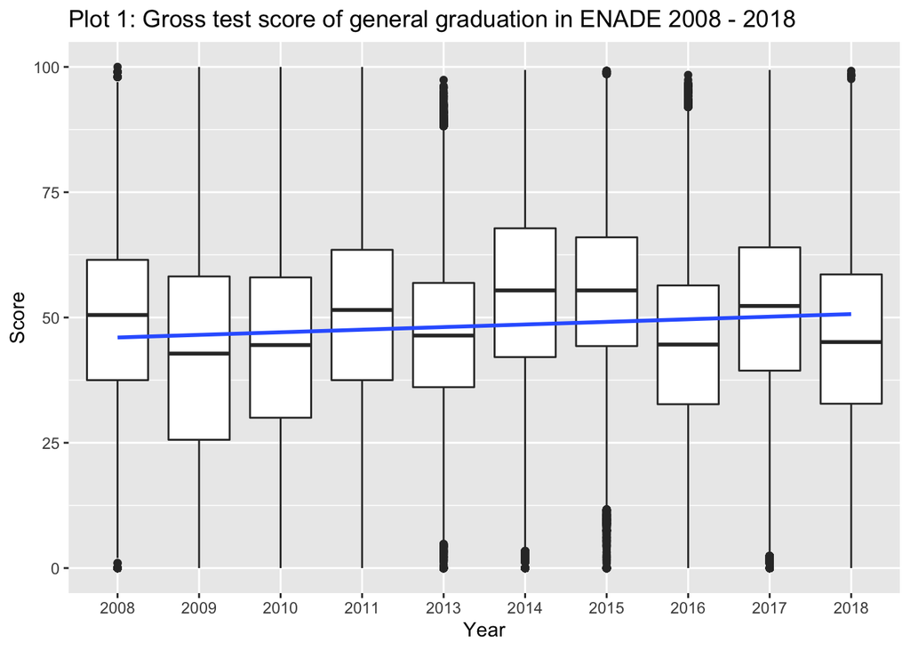

### 4.1.2. Gross test score of the specific component

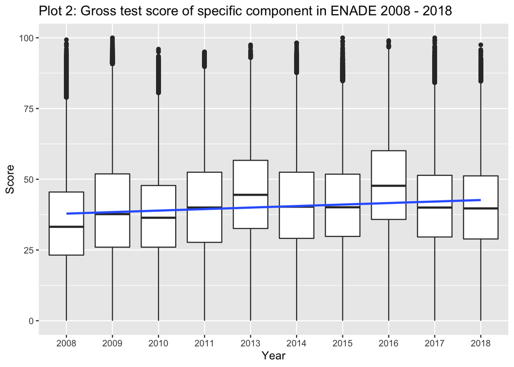

### 4.1.3. Gross test score (overall scores)

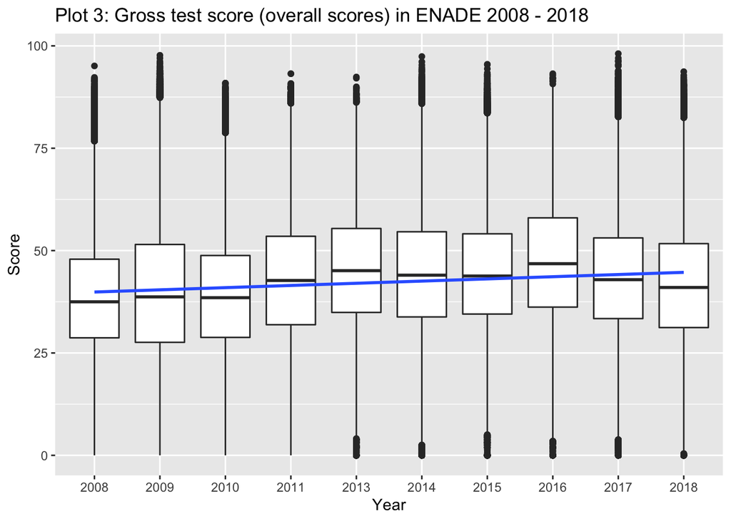

### 4.1.4. General Notes

```r
summary(comparedf(mData2011, mData2012))
```

```
##
##
## Table: Summary of data.frames
##
## version   arg          ncol     nrow
## --------  ----------  -----  -------
## x         mData2011     115   376180
## y         mData2012     115   376180
##
##
##
## Table: Summary of overall comparison
##
## statistic                                                       value
## ------------------------------------------------------------  -------
## Number of by-variables                                              0
## Number of non-by variables in common                              115
## Number of variables compared                                      115
## Number of variables in x but not y                                  0
## Number of variables in y but not x                                  0
## Number of variables compared with some values unequal               0
## Number of variables compared with all values equal                115
## Number of observations in common                               376180
## Number of observations in x but not y                               0
## Number of observations in y but not x                               0
## Number of observations with some compared variables unequal         0
## Number of observations with all compared variables equal       376180
## Number of values unequal                                            0
##
##
##
## Table: Variables not shared
##
## |                        |
## |:-----------------------|
## |No variables not shared |
##
##
##
## Table: Other variables not compared
```

[output cut: 135 more lines]

```
##
##
## Table: Differences detected
##
## |                        |
## |:-----------------------|
## |No differences detected |
##
##
##
## Table: Non-identical attributes
##
## |                            |
## |:---------------------------|
## |No non-identical attributes |
```

| Table 5: Improving Taxs Variables | Table 5: Improving Taxs Description | Table 5: Improving Taxs Tax…. |
| --- | --- | --- |
| NT_FG | Gross test score of general graduation | 0.3057377 |
| NT_CE | Gross test score of the specific component | 0.3049391 |
| NT_GER | Gross test score | 0.3057377 |

## 4.2 Where Brazil have the best number in education? per region and per courses in each region

### 4.2.1 Per Region

The table bellow, shows regions codes in Brazil and states.

| Table 6: Brazil Regions Id | Table 6: Brazil Regions Region | Table 6: Brazil Regions States |
| --- | --- | --- |
| 1 | North | Rondônia, Acre, Amazonas, Roraima, Pará, Amapa, Tocantins |
| 2 | Northeast | Maranhão, Piauí, Ceará, Rio Grande do Norte, Paraíba, Pernambuco, Alagoas, Sergipe, Bahia |
| 3 | Southeast | Minas Gerais, Espirito Santo, Rio de Janeiro, São Paulo |
| 4 | South | Paraná, Santa Catarina, Rio Grande do Sul |
| 5 | Midwest | Mato Grosso do Sul, Mato Grosso, Goiás, Distrito Federal |

To address this question, the analysis must show if the Gross test score of general graduation (NT_FG), Gross test score of the specific component (NT_CE) and Gross test score (NT_GER) for each region in Brazil.

#### 4.2.1.1 Gross test score of general graduation per Region

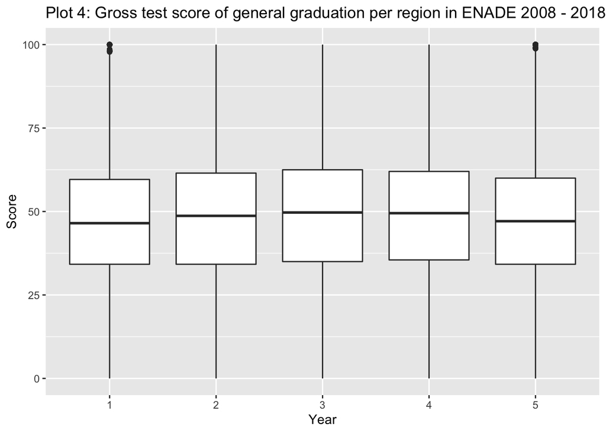

#### 4.2.1.2. Gross test score of the specific component per Region

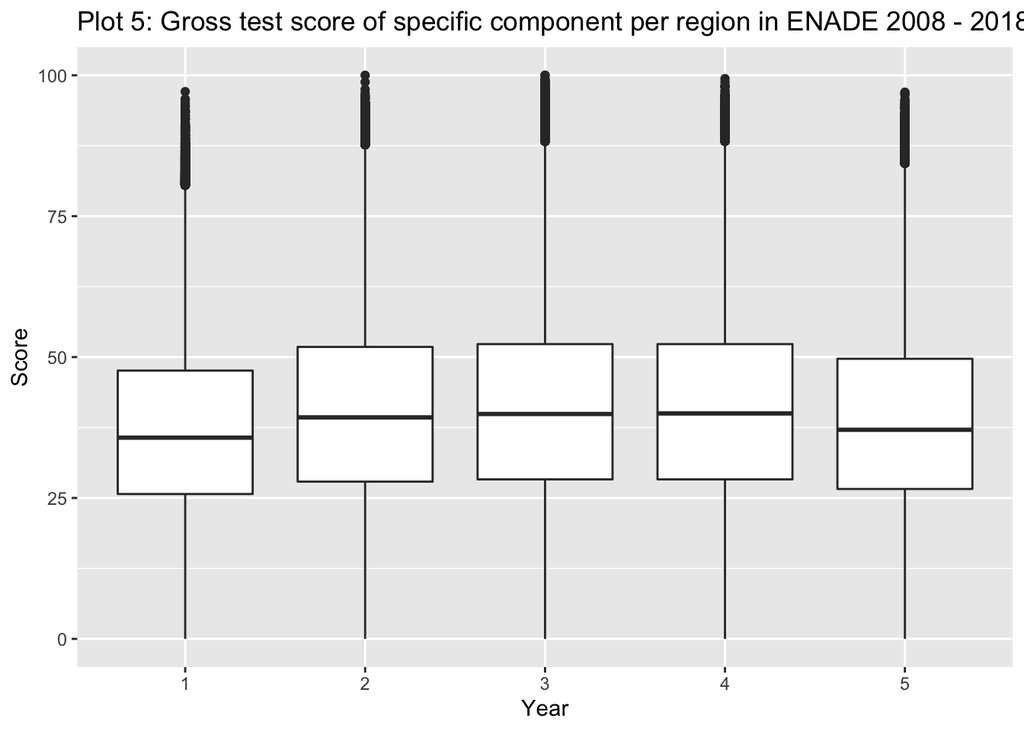

#### 4.2.1.3. Gross test score (overall scores) per Region

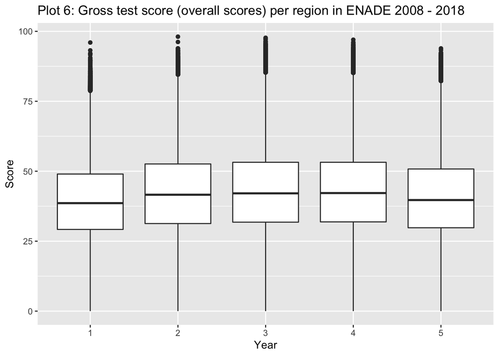

#### 4.2.1.4. General Notes per region

According with tables bellow the best mean grade are in region 4 and 3 followed by region 2 in brazil from 2008 to 2018 for the gross test score (overall scores), gross test score for specific component and gross test score of general graduation.

```r
rt_nt_ger <- tapply(mData$NT_GER, mData$CO_REGIAO_CURSO, mean, na.rm = TRUE)
rt_nt_ce <- tapply(mData$NT_CE, mData$CO_REGIAO_CURSO, mean, na.rm = TRUE)
rt_nt_fg <- tapply(mData$NT_FG, mData$CO_REGIAO_CURSO, mean, na.rm = TRUE)

tbl7 <- data.frame("Id" = c("1","2","3","4","5"),rt_nt_ger, rt_nt_ce, rt_nt_fg)

colnames(tbl7) <- c("Region", "NT_GER", "NT_CE", "NT_FG")

kable(tbl7) %>%
        add_header_above(c("Table 7: Average grades by Region in Brazil" = 4)) %>%
       kable_styling(full_width = F) %>%
        column_spec(1, bold=T, border_right = T)
```

| Table 7: Average grades by Region in Brazil Region | Table 7: Average grades by Region in Brazil NT_GER | Table 7: Average grades by Region in Brazil NT_CE | Table 7: Average grades by Region in Brazil NT_FG |
| --- | --- | --- | --- |
| 1 | 39.37670 | 37.06079 | 46.30147 |
| 2 | 42.04621 | 40.13274 | 47.78864 |
| 3 | 42.58323 | 40.54366 | 48.69079 |
| 4 | 42.70731 | 40.71251 | 48.67773 |
| 5 | 40.57024 | 38.52546 | 46.69502 |

### 4.2.2 Per Courses each region.

This section will address questions about the best upper graduation course in each region of Brazil. Historically each region has best courses in some fields of study then others. Based on those courses is possible to identify the power of the region in different subjects.

```r
# Get a subset to be analyse
mDataRegion <- data.frame(mData$CO_REGIAO_CURSO, mData$CO_CURSO, mData$NT_GER, mData$NT_FG, mData$NT_CE)
colnames(mDataRegion) <- c("CO_REGIAO_CURSO", "CO_CURSO", "NT_GER", "NT_FG", "NT_CE")

# Define factors
mDataRegion$CO_CURSO <- as.numeric(mDataRegion$CO_CURSO)
mDataRegion$CO_CURSO <- as.factor(mDataRegion$CO_CURSO)
mDataRegion$CO_REGIAO_CURSO <- as.factor(mDataRegion$CO_REGIAO_CURSO)
```

#### 4.2.2.1 Region 1 - North

The top 15 Upper graduation course in region 1 for all grade are showed bellow:

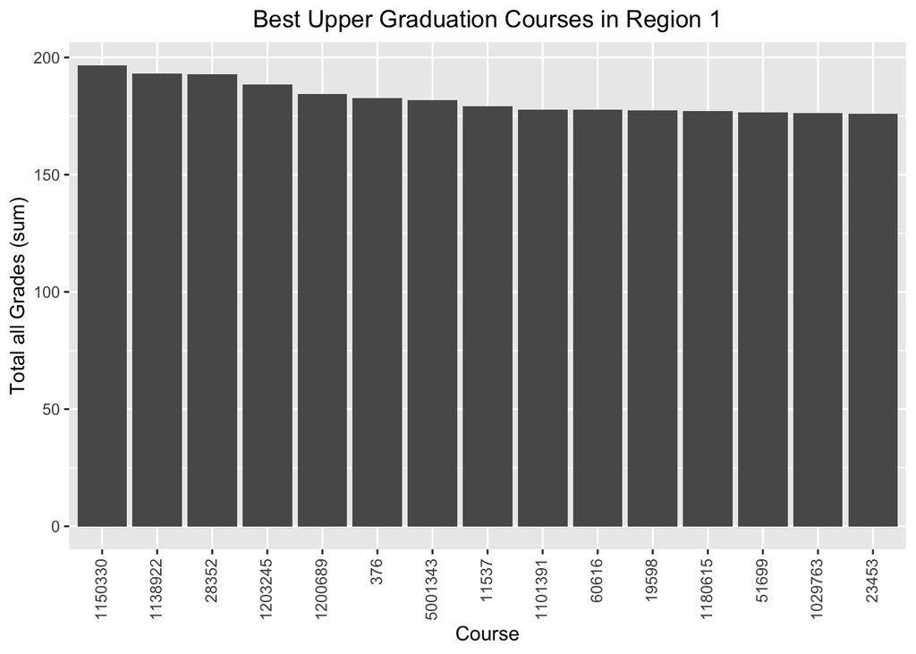

```r
# Get subset analysis for region
r1 <- subset(mDataRegion, CO_REGIAO_CURSO == 1, na.rm = TRUE)

# Calculate mean per courses
r1NT_GER <- aggregate(r1$NT_GER, list(r1$CO_CURSO), mean, na.rm = TRUE)
r1NT_FG <- aggregate(r1$NT_FG, list(r1$CO_CURSO), mean, na.rm = TRUE)
r1NT_CE <- aggregate(r1$NT_CE, list(r1$CO_CURSO), mean, na.rm = TRUE)

# Merge analysis
r1Data <- merge(r1NT_GER, r1NT_FG, "Group.1")
r1Data <- merge(r1Data, r1NT_CE, "Group.1")
colnames(r1Data) <- c("CO_CURSO", "NT_GER", "NT_FG", "NT_CE")

# Add total grades and order desc
r1Data$TOTAL <- r1Data$NT_GER + r1Data$NT_FG + r1Data$NT_CE
r1Data <- r1Data[order(-r1Data$TOTAL),]

# Plot top 15 best upper graduation course per region

# Get data to plot Top 15
plotData1 <- r1Data[1:15,]
plotData1 <- merge(plotData1, tblCursos, "CO_CURSO")

#Plot data
ggplot(plotData1, aes(x=reorder(CO_CURSO, -TOTAL), y=TOTAL)) + geom_bar(stat="identity", fill="forest green") + geom_bar(stat="identity") + theme(axis.text.x = element_text(angle = 90, vjust = 0.4, hjust = 1), plot.title = element_text(hjust = 0.5)) + ggtitle("Best Upper Graduation Courses in Region 1") + xlab("Course") + ylab("Total all Grades (sum)")
```

Each course has a number that has been identified according with INEP. Bellow has the code table for each best 15 upper graduation course in region 1.

```r
#Prepare for print table
tblPlotData1 <- data.frame(plotData1$CO_CURSO, plotData1$TOTAL, plotData1$NOME, plotData1$NIVEL_ACADEMICO, plotData1$MODALIDADE, plotData1$GRAU_ACADEMICO)

#Rename Columns
colnames(tblPlotData1) <- c("COURSE_COD", "ALL_SCORE", "COURSE", "LEVEL", "MOD", "ACADEMIC_LEVEL")

#Order by Score
tblPlotData1 <- tblPlotData1[order(-tblPlotData1$ALL_SCORE),]

#Print Table
kable(tblPlotData1) %>%
        ## add_header_above(c("Table X: Best Upper Graduation Courses in Region 1" = 6)) %>%
       kable_styling(full_width = F) %>%
        column_spec(1, bold=T, border_right = T)
```

|  | COURSE_COD | ALL_SCORE | COURSE | LEVEL | MOD | ACADEMIC_LEVEL |
| --- | --- | --- | --- | --- | --- | --- |
| 4 | 1150330 | 196.7250 | AUTOMAÇÃO INDUSTRIAL | Graduação | Presencial | Tecnológico |
| 3 | 1138922 | 193.2348 | AGRONOMIA | Graduação | Presencial | Bacharelado |
| 11 | 28352 | 192.9864 | COMUNICAÇÃO SOCIAL - PUBLICIDADE E PROPAGANDA | Graduação | Presencial | Bacharelado |
| 8 | 1203245 | 188.5988 | ADMINISTRAÇÃO PÚBLICA | Graduação | A distancia | Bacharelado |
| 7 | 1200689 | 184.4333 | FARMÁCIA | Graduação | Presencial | Bacharelado |
| 12 | 376 | 182.8016 | DIREITO | Graduação | Presencial | Bacharelado |
| 13 | 5001343 | 181.6724 | PSICOLOGIA | Graduação | Presencial | Bacharelado |
| 5 | 11537 | 179.1452 | DIREITO | Graduação | Presencial | Bacharelado |
| 2 | 1101391 | 177.8291 | ENGENHARIA CIVIL | Graduação | Presencial | Bacharelado |
| 15 | 60616 | 177.8139 | DIREITO | Graduação | Presencial | Bacharelado |
| 9 | 19598 | 177.5362 | DIREITO | Graduação | Presencial | Bacharelado |
| 6 | 1180615 | 177.1833 | PROCESSOS GERENCIAIS | Graduação | Presencial | Tecnológico |
| 14 | 51699 | 176.6344 | MEDICINA | Graduação | Presencial | Bacharelado |
| 1 | 1029763 | 176.2649 | MEDICINA | Graduação | Presencial | Bacharelado |
| 10 | 23453 | 175.9304 | PUBLICIDADE E PROPAGANDA | Graduação | Presencial | Bacharelado |

#### 4.2.2.2 Region 2 - Northeast

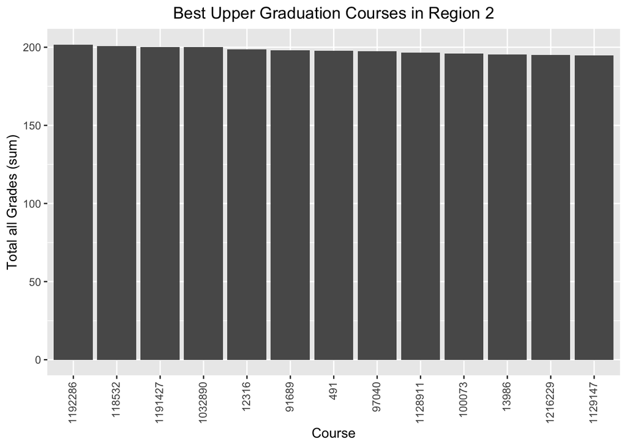

```r
# Get subset analysis for region
r2 <- subset(mDataRegion, CO_REGIAO_CURSO == 2, na.rm = TRUE)

# Calculate mean per courses
r2NT_GER <- aggregate(r2$NT_GER, list(r2$CO_CURSO), mean, na.rm = TRUE)
r2NT_FG <- aggregate(r2$NT_FG, list(r2$CO_CURSO), mean, na.rm = TRUE)
r2NT_CE <- aggregate(r2$NT_CE, list(r2$CO_CURSO), mean, na.rm = TRUE)

# Merge analysis
r2Data <- merge(r2NT_GER, r2NT_FG, "Group.1")
r2Data <- merge(r2Data, r2NT_CE, "Group.1")
colnames(r2Data) <- c("CO_CURSO", "NT_GER", "NT_FG", "NT_CE")

# Add total grades and order desc
r2Data$TOTAL <- r2Data$NT_GER + r2Data$NT_FG + r2Data$NT_CE
r2Data <- r2Data[order(-r2Data$TOTAL),]

# Plot top 15 best upper graduation course per region

# Get data to plot Top 15
plotData2 <- r2Data[1:15,]
plotData2 <- merge(plotData2, tblCursos, "CO_CURSO")

#Plot data
ggplot(plotData2, aes(x=reorder(CO_CURSO, -TOTAL), y=TOTAL)) + geom_bar(stat="identity", fill="forest green") + geom_bar(stat="identity") + theme(axis.text.x = element_text(angle = 90, vjust = 0.4, hjust = 1), plot.title = element_text(hjust = 0.5)) + ggtitle("Best Upper Graduation Courses in Region 2") + xlab("Course") + ylab("Total all Grades (sum)")
```

```r
tblPlotData2 <- data.frame(plotData2$CO_CURSO, plotData2$TOTAL, plotData2$NOME, plotData2$NIVEL_ACADEMICO, plotData2$MODALIDADE, plotData2$GRAU_ACADEMICO)

colnames(tblPlotData2) <- c("COURSE_COD", "ALL_SCORE", "COURSE", "LEVEL", "MOD", "ACADEMIC_LEVEL")

tblPlotData2 <- tblPlotData2[order(-tblPlotData2$ALL_SCORE),]

kable(tblPlotData2) %>%
        ##add_header_above(c("Table X: Best Upper Graduation Courses in Region 2" = 6)) %>%
       kable_styling(full_width = F) %>%
        column_spec(1, bold=T, border_right = T)
```

|  | COURSE_COD | ALL_SCORE | COURSE | LEVEL | MOD | ACADEMIC_LEVEL |
| --- | --- | --- | --- | --- | --- | --- |
| 7 | 1192286 | 201.7250 | ARQUITETURA E URBANISMO | Graduação | Presencial | Bacharelado |
| 5 | 118532 | 200.7000 | EDUCAÇÃO FÍSICA | Graduação | Presencial | Licenciatura |
| 6 | 1191427 | 200.2444 | EDUCAÇÃO FÍSICA | Graduação | Presencial | Licenciatura |
| 2 | 1032890 | 200.0840 | DIREITO | Graduação | Presencial | Bacharelado |
| 9 | 12316 | 198.5598 | PSICOLOGIA | Graduação | Presencial | Bacharelado |
| 12 | 91689 | 198.0500 | PEDAGOGIA | Graduação | Presencial | Licenciatura |
| 11 | 491 | 197.7680 | DIREITO | Graduação | Presencial | Bacharelado |
| 13 | 97040 | 197.5800 | MÚSICA - EDUCAÇÃO MUSICAL | Graduação | Presencial | Licenciatura |
| 3 | 1128911 | 196.5040 | LETRAS - INGLÊS | Graduação | Presencial | Licenciatura |
| 1 | 100073 | 195.9308 | ENFERMAGEM | Graduação | Presencial | Bacharelado |
| 10 | 13986 | 195.3908 | PSICOLOGIA | Graduação | Presencial | Bacharelado |
| 8 | 1216229 | 195.0077 | DIREITO | Graduação | Presencial | Bacharelado |
| 4 | 1129147 | 194.8804 | ARQUITETURA E URBANISMO | Graduação | Presencial | Bacharelado |

#### 4.2.2.3 Region 3 - Southeast

The top 15 Upper graduation course in region 3 for all grade are showed bellow:

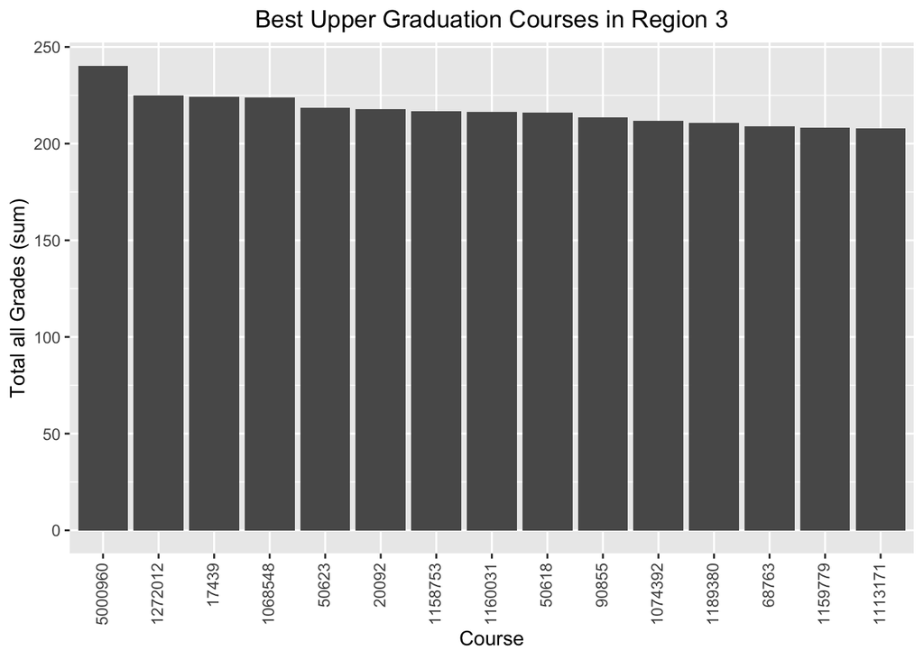

```r
# Get subset analysis for region
r3 <- subset(mDataRegion, CO_REGIAO_CURSO == 3, na.rm = TRUE)

# Calculate mean per courses
r3NT_GER <- aggregate(r3$NT_GER, list(r3$CO_CURSO), mean, na.rm = TRUE)
r3NT_FG <- aggregate(r3$NT_FG, list(r3$CO_CURSO), mean, na.rm = TRUE)
r3NT_CE <- aggregate(r3$NT_CE, list(r3$CO_CURSO), mean, na.rm = TRUE)

# Merge analysis
r3Data <- merge(r3NT_GER, r3NT_FG, "Group.1")
r3Data <- merge(r3Data, r3NT_CE, "Group.1")
colnames(r3Data) <- c("CO_CURSO", "NT_GER", "NT_FG", "NT_CE")

# Add total grades and order desc
r3Data$TOTAL <- r3Data$NT_GER + r3Data$NT_FG + r3Data$NT_CE
r3Data <- r3Data[order(-r3Data$TOTAL),]

# Plot top 15 best upper graduation course per region

# Get data to plot Top 15
plotData3 <- r3Data[1:15,]
plotData3 <- merge(plotData3, tblCursos, "CO_CURSO")

#Plot data
ggplot(plotData3, aes(x=reorder(CO_CURSO, -TOTAL), y=TOTAL)) + geom_bar(stat="identity", fill="forest green") + geom_bar(stat="identity") + theme(axis.text.x = element_text(angle = 90, vjust = 0.4, hjust = 1), plot.title = element_text(hjust = 0.5)) + ggtitle("Best Upper Graduation Courses in Region 3") + xlab("Course") + ylab("Total all Grades (sum)")
```

Each course has a number that has been identified according with INEP. Bellow has the code table for each best 15 upper graduation course in region 3.

```r
tblPlotData3 <- data.frame(plotData3$CO_CURSO, plotData3$TOTAL, plotData3$NOME, plotData3$NIVEL_ACADEMICO, plotData3$MODALIDADE, plotData3$GRAU_ACADEMICO)

colnames(tblPlotData3) <- c("COURSE_COD", "ALL_SCORE", "COURSE", "LEVEL", "MOD", "ACADEMIC_LEVEL")


tblPlotData3 <- tblPlotData3[order(-tblPlotData3$ALL_SCORE),]

kable(tblPlotData3) %>%
       ## add_header_above(c("Table X: Best Upper Graduation Courses in Region 3" = 6)) %>%
       kable_styling(full_width = F) %>%
        column_spec(1, bold=T, border_right = T)
```

|  | COURSE_COD | ALL_SCORE | COURSE | LEVEL | MOD | ACADEMIC_LEVEL |
| --- | --- | --- | --- | --- | --- | --- |
| 11 | 5000960 | 240.3091 | ENGENHARIA AEROESPACIAL | Graduação | Presencial | Bacharelado |
| 8 | 1272012 | 225.0500 | SISTEMAS DE INFORMAÇÃO | Graduação | Presencial | Bacharelado |
| 9 | 17439 | 224.1895 | ADMINISTRAÇÃO PÚBLICA | Graduação | Presencial | Bacharelado |
| 1 | 1068548 | 223.8178 | MEDICINA | Graduação | Presencial | Bacharelado |
| 13 | 50623 | 218.4000 | ENGENHARIA MECÂNICA E DE AUTOMÓVEIS | Graduação | Presencial | Bacharelado |
| 10 | 20092 | 217.9000 | TURISMO | Graduação | Presencial | Bacharelado |
| 4 | 1158753 | 216.7000 | AUTOMAÇÃO INDUSTRIAL | Graduação | Presencial | Tecnológico |
| 6 | 1160031 | 216.2333 | NUTRIÇÃO | Graduação | Presencial | Bacharelado |
| 12 | 50618 | 216.1348 | ENGENHARIA DE FORTIFICAÇÃO E CONSTRUÇÃO | Graduação | Presencial | Bacharelado |
| 15 | 90855 | 213.6222 | ADMINISTRAÇÃO | Graduação | Presencial | Bacharelado |
| 2 | 1074392 | 211.6250 | MATEMÁTICA | Graduação | Presencial | Bacharelado |
| 7 | 1189380 | 210.6800 | CIÊNCIAS BIOLÓGICAS | Graduação | Presencial | Licenciatura |
| 14 | 68763 | 208.8121 | PROCESSOS GERENCIAIS | Graduação | Presencial | Tecnológico |
| 5 | 1159779 | 208.1600 | FILOSOFIA | Graduação | Presencial | Licenciatura |
| 3 | 1113171 | 207.8462 | COMUNICAÇÃO SOCIAL - PUBLICIDADE | Graduação | Presencial | Bacharelado |

#### 4.2.2.4 Region 4 - South

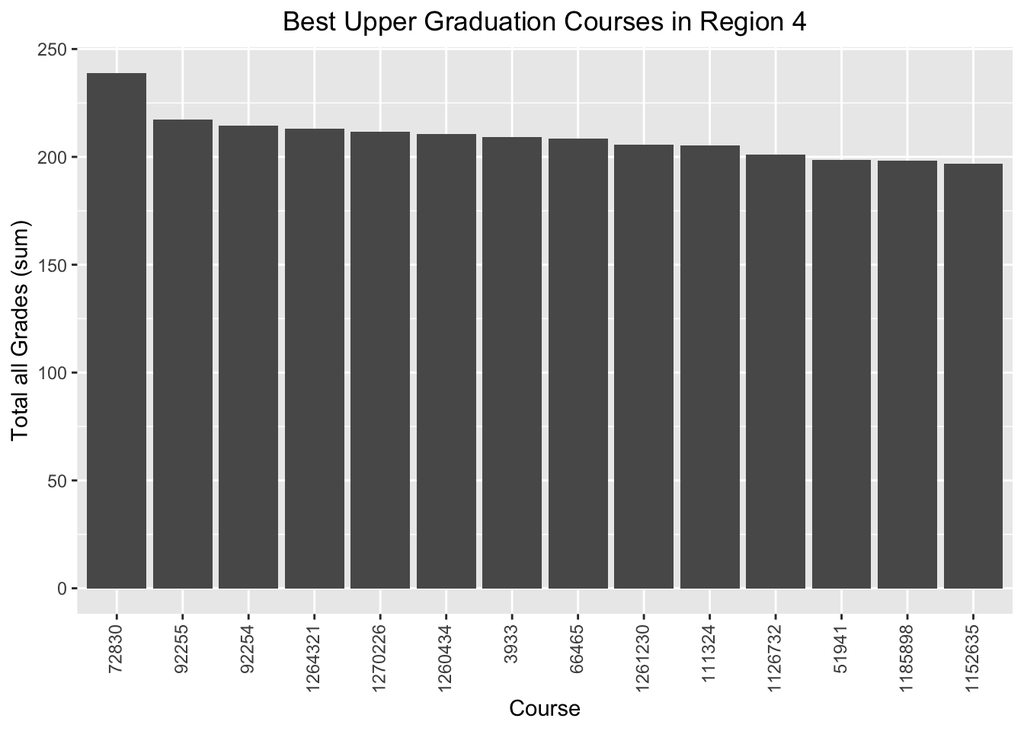

```r
# Get subset analysis for region
r4 <- subset(mDataRegion, CO_REGIAO_CURSO == 4, na.rm = TRUE)

# Calculate mean per courses
r4NT_GER <- aggregate(r4$NT_GER, list(r4$CO_CURSO), mean, na.rm = TRUE)
r4NT_FG <- aggregate(r4$NT_FG, list(r4$CO_CURSO), mean, na.rm = TRUE)
r4NT_CE <- aggregate(r4$NT_CE, list(r4$CO_CURSO), mean, na.rm = TRUE)

# Merge analysis
r4Data <- merge(r4NT_GER, r4NT_FG, "Group.1")
r4Data <- merge(r4Data, r4NT_CE, "Group.1")
colnames(r4Data) <- c("CO_CURSO", "NT_GER", "NT_FG", "NT_CE")

# Add total grades and order desc
r4Data$TOTAL <- r4Data$NT_GER + r4Data$NT_FG + r4Data$NT_CE
r4Data <- r4Data[order(-r4Data$TOTAL),]

# Plot top 15 best upper graduation course per region

# Get data to plot Top 15
plotData4 <- r4Data[1:15,]
plotData4 <- merge(plotData4, tblCursos, "CO_CURSO")

#Plot data
ggplot(plotData4, aes(x=reorder(CO_CURSO, -TOTAL), y=TOTAL)) + geom_bar(stat="identity", fill="forest green") + geom_bar(stat="identity") + theme(axis.text.x = element_text(angle = 90, vjust = 0.4, hjust = 1), plot.title = element_text(hjust = 0.5)) + ggtitle("Best Upper Graduation Courses in Region 4") + xlab("Course") + ylab("Total all Grades (sum)")
```

```r
tblPlotData4 <- data.frame(plotData4$CO_CURSO, plotData4$TOTAL, plotData4$NOME, plotData4$NIVEL_ACADEMICO, plotData4$MODALIDADE, plotData4$GRAU_ACADEMICO)

colnames(tblPlotData4) <- c("COURSE_COD", "ALL_SCORE", "COURSE", "LEVEL", "MOD", "ACADEMIC_LEVEL")


tblPlotData4 <- tblPlotData4[order(-tblPlotData4$ALL_SCORE),]

kable(tblPlotData4) %>%
       ## add_header_above(c("Table X: Best Upper Graduation Courses in Region 4" = 6)) %>%
       kable_styling(full_width = F) %>%
        column_spec(1, bold=T, border_right = T)
```

|  | COURSE_COD | ALL_SCORE | COURSE | LEVEL | MOD | ACADEMIC_LEVEL |
| --- | --- | --- | --- | --- | --- | --- |
| 12 | 72830 | 238.9500 | ARTES GRÁFICAS | Graduação | Presencial | Tecnológico |
| 14 | 92255 | 217.2692 | LETRAS PORTUGUÊS E INGLÊS | Graduação | Presencial | Licenciatura |
| 13 | 92254 | 214.6500 | LETRAS - FRANCÊS | Graduação | Presencial | Licenciatura |
| 7 | 1264321 | 212.9000 | MATEMÁTICA | Graduação | Presencial | Licenciatura |
| 8 | 1270226 | 211.6000 | COMPUTAÇÃO | Graduação | Presencial | Licenciatura |
| 5 | 1260434 | 210.5600 | MATEMÁTICA | Graduação | Presencial | Licenciatura |
| 9 | 3933 | 209.0500 | PEDAGOGIA | Graduação | Presencial | Licenciatura |
| 11 | 66465 | 208.6142 | RELAÇÕES INTERNACIONAIS | Graduação | Presencial | Bacharelado |
| 6 | 1261230 | 205.7692 | ENGENHARIA CIVIL | Graduação | Presencial | Bacharelado |
| 1 | 111324 | 205.4667 | LETRAS - LÍNGUA ESTRANGEIRA | Graduação | Presencial | Licenciatura |
| 2 | 1126732 | 201.0036 | GASTRONOMIA | Graduação | Presencial | Tecnológico |
| 10 | 51941 | 198.6333 | LETRAS - INGLÊS | Graduação | Presencial | Licenciatura |
| 4 | 1185898 | 198.2500 | ENGENHARIA MECÂNICA | Graduação | Presencial | Bacharelado |
| 3 | 1152635 | 196.9541 | AGRONOMIA | Graduação | Presencial | Bacharelado |